# Predicting Frequently Reviewed Businesses

November 21, 2015

Data Science Specialization - Capstone Project  
Yelp Dataset Challenge

### Challenge

For the Capstone Project within their Data Science Specialization, Coursera offered students to participate in the Yelp Dataset Challenge (Round 6). The dataset consists of

- 1.6M reviews and 500K tips by 366K users for 61K businesses
- 481K business attributes, e.g., hours, parking availability, ambience.
- Social network of 366K users for a total of 2.9M social edges.
- Aggregated check-ins over time for each of the 61K businesses

**Our question:** Can we predict if a business is likely to receive more than 100 reviews?

### Prediction Modeling

- Decision Trees
  - Recursive partitioning and regression trees
  - Rpart package
- Linear models
  - Logistic Regression
  - GLM package
- Many predictors
  - Review count
  - Stars
  - Business price range
  - …

### Results

- Below is a summary of some of our experiments with logistic regression:

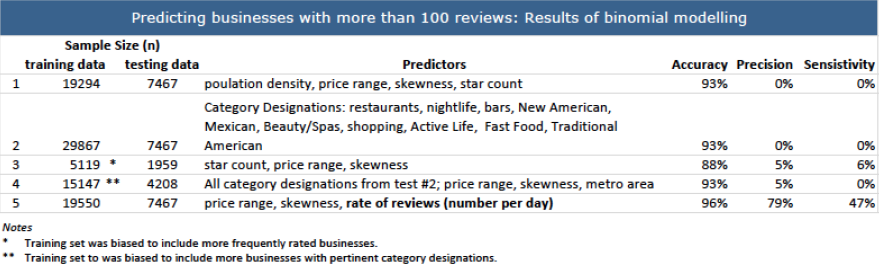

- The most useful predictor seems to be the number of reviews generated per day

### Conclusion

- Our statistical models were somewhat successful at predicting frequently reviewed businesses
- Many predictors were explored but further research is required to determine more effective predictor variables
- In future work, we could investigate sentiment and topic analysis with the hope of making better predictions